# Multiple Linear Regression.

Fiston Niyigena

2026-11-17

# Load the dataset

```r
data(mtcars)

# Display the first six observations
head(mtcars)
```

```
##                    mpg cyl disp  hp drat    wt  qsec vs am gear carb
## Mazda RX4         21.0   6  160 110 3.90 2.620 16.46  0  1    4    4
## Mazda RX4 Wag     21.0   6  160 110 3.90 2.875 17.02  0  1    4    4
## Datsun 710        22.8   4  108  93 3.85 2.320 18.61  1  1    4    1
## Hornet 4 Drive    21.4   6  258 110 3.08 3.215 19.44  1  0    3    1
## Hornet Sportabout 18.7   8  360 175 3.15 3.440 17.02  0  0    3    2
## Valiant           18.1   6  225 105 2.76 3.460 20.22  1  0    3    1
```

# Data Exploration

```r
# Check data structure
str(mtcars)
```

```
## 'data.frame':    32 obs. of  11 variables:
##  $ mpg : num  21 21 22.8 21.4 18.7 18.1 14.3 24.4 22.8 19.2 ...
##  $ cyl : num  6 6 4 6 8 6 8 4 4 6 ...
##  $ disp: num  160 160 108 258 360 ...
##  $ hp  : num  110 110 93 110 175 105 245 62 95 123 ...
##  $ drat: num  3.9 3.9 3.85 3.08 3.15 2.76 3.21 3.69 3.92 3.92 ...
##  $ wt  : num  2.62 2.88 2.32 3.21 3.44 ...
##  $ qsec: num  16.5 17 18.6 19.4 17 ...
##  $ vs  : num  0 0 1 1 0 1 0 1 1 1 ...
##  $ am  : num  1 1 1 0 0 0 0 0 0 0 ...
##  $ gear: num  4 4 4 3 3 3 3 4 4 4 ...
##  $ carb: num  4 4 1 1 2 1 4 2 2 4 ...
```

```r
# Select relevant variables
data <- mtcars[, c("mpg", "wt", "hp")]

# Summary statistics
summary(data)
```

```
##       mpg              wt              hp
##  Min.   :10.40   Min.   :1.513   Min.   : 52.0
##  1st Qu.:15.43   1st Qu.:2.581   1st Qu.: 96.5
##  Median :19.20   Median :3.325   Median :123.0
##  Mean   :20.09   Mean   :3.217   Mean   :146.7
##  3rd Qu.:22.80   3rd Qu.:3.610   3rd Qu.:180.0
##  Max.   :33.90   Max.   :5.424   Max.   :335.0
```

```r
# Check missing values
colSums(is.na(data))
```

```
## mpg  wt  hp
##   0   0   0
```

# Data Visualization

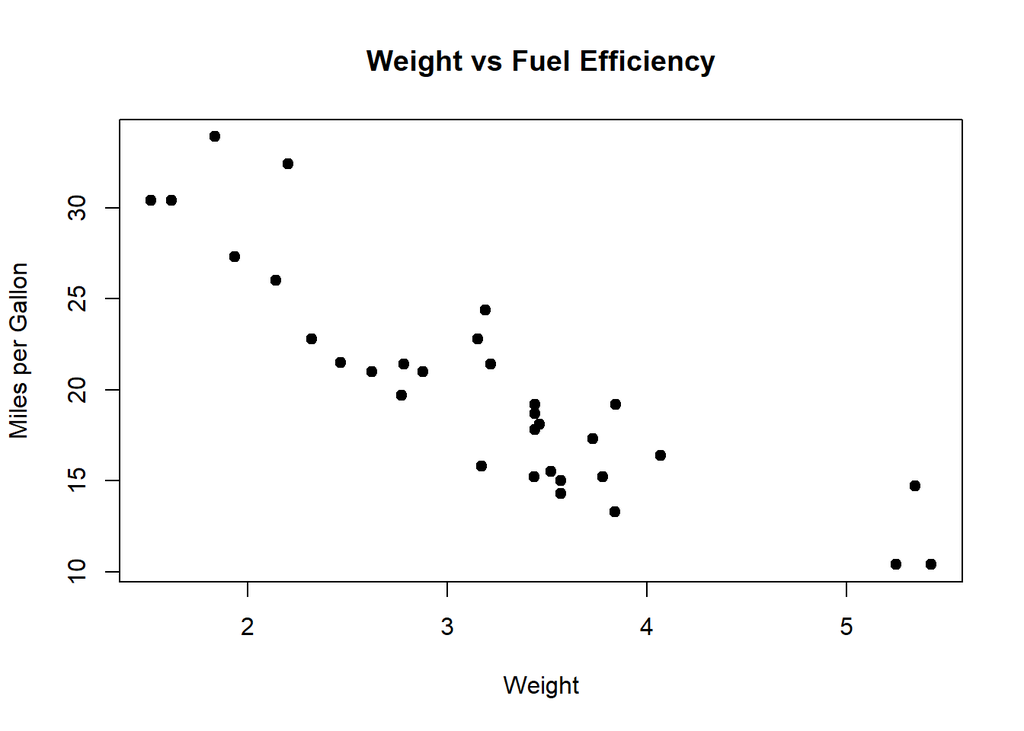

```r
# Relationship between weight and fuel efficiency
plot(data$wt, data$mpg,
     main = "Weight vs Fuel Efficiency",
     xlab = "Weight",
     ylab = "Miles per Gallon",
     pch = 19)
```

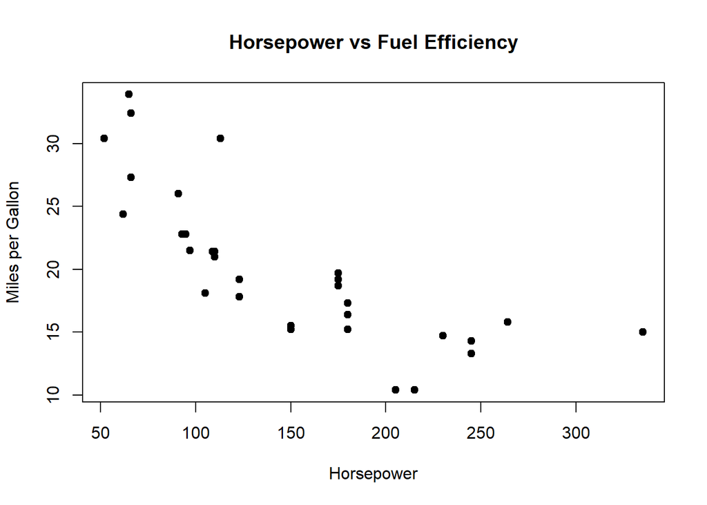

```r
# Relationship between horsepower and fuel efficiency
plot(data$hp, data$mpg,
     main = "Horsepower vs Fuel Efficiency",
     xlab = "Horsepower",
     ylab = "Miles per Gallon",
     pch = 19)
```

# Multiple Linear Regression Model

The regression model is:

MPG = β0 + β1(WT) + β2(HP) + ε

```r
# Fit the regression model
model <- lm(mpg ~ wt + hp, data = data)

# Display regression results
summary(model)
```

```
##
## Call:
## lm(formula = mpg ~ wt + hp, data = data)
##
## Residuals:
##    Min     1Q Median     3Q    Max
## -3.941 -1.600 -0.182  1.050  5.854
##
## Coefficients:
##             Estimate Std. Error t value Pr(>|t|)
## (Intercept) 37.22727    1.59879  23.285  < 2e-16 ***
## wt          -3.87783    0.63273  -6.129 1.12e-06 ***
## hp          -0.03177    0.00903  -3.519  0.00145 **
## ---
## Signif. codes:  0 '***' 0.001 '**' 0.01 '*' 0.05 '.' 0.1 ' ' 1
##
## Residual standard error: 2.593 on 29 degrees of freedom
## Multiple R-squared:  0.8268, Adjusted R-squared:  0.8148
## F-statistic: 69.21 on 2 and 29 DF,  p-value: 9.109e-12
```

# Interpretation of Results

```r
# Extract regression coefficients
coef(model)
```

```
## (Intercept)          wt          hp
## 37.22727012 -3.87783074 -0.03177295
```

```r
# Display R-squared
summary(model)$r.squared
```

```
## [1] 0.8267855
```

```r
# Display adjusted R-squared
summary(model)$adj.r.squared
```

```
## [1] 0.8148396
```

```r
# Display F-statistic and p-value
summary(model)$fstatistic
```

```
##    value    numdf    dendf
## 69.21121  2.00000 29.00000
```

The regression equation is approximately:

MPG = 37.227 - 3.878(WT) - 0.032(HP)

Interpretation of Results

- Intercept (37.227): Expected fuel efficiency when weight and horsepower are zero.
- Weight (-3.878): Increasing weight by 1,000 pounds reduces fuel efficiency by 3.878 MPG.
- Horsepower (-0.032): Increasing horsepower by one unit reduces fuel efficiency by 0.032 MPG.
- R-squared (82.68%): Weight and horsepower explain 82.68% of the changes in fuel efficiency.

#Regression Diagnostics

Regression diagnostics help assess whether the assumptions of multiple linear regression are satisfied.

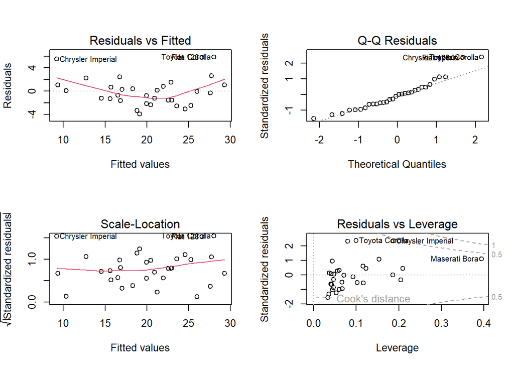

```r
# Display diagnostic plots
par(mfrow = c(2, 2))
plot(model)
```

```r
par(mfrow = c(1, 1))
```

#Normality Test

```r
# Shapiro-Wilk normality test
shapiro.test(residuals(model))
```

```
##
##  Shapiro-Wilk normality test
##
## data:  residuals(model)
## W = 0.92792, p-value = 0.03427
```

Interpretation:

If the p-value is greater than 0.05, there is insufficient evidence to reject the assumption of normally distributed residuals.

# Multicollinearity Test

```r
# Correlation between independent variables
cor(data$wt, data$hp)
```

```
## [1] 0.6587479
```

A high correlation may indicate multicollinearity between the independent variables.

# Homoscedasticity Test

```r
library(lmtest)
# Breusch-Pagan test
bptest(model)
```

```
##
##  studentized Breusch-Pagan test
##
## data:  model
## BP = 0.88072, df = 2, p-value = 0.6438
```

Interpretation:

- p-value greater than 0.05: No significant evidence of heteroscedasticity.
- p-value less than 0.05: Evidence of heteroscedasticity.

# Prediction

```r
# Predict fuel efficiency for a vehicle
new_car <- data.frame(wt = 3.0, hp = 120)

predict(model, newdata = new_car)
```

```
##        1
## 21.78102
```

This predicts fuel efficiency for a vehicle weighing 3,000 pounds and having 120 horsepower.

#Conclusion

The results show that heavier cars and cars with higher horsepower use more fuel. Our model explains 82.68% of the differences in fuel efficiency. This shows that multiple linear regression helps us understand how several factors affect one outcome.